*Título:* Brecha Salarial a través de los años(2004-2020) en las distintas regiones/departamentos del país *Título corto:* Brecha salarial en regiones/departamentos del Perú

*1. Introducción*

*a). Importancia* “El Perú es el país con mayor brecha salarial entre los puestos ejecutivos y operativos en Sudamérica, según la Encuesta de Remuneración Total 2020, elaborada por la consultora empresarial Mercer” (Gestión, R., 2020)

*b).Justificación del trabajo*

Los datos serán recolectados de las bases de datos disponibles en la página del Instituto Nacional de Estadística e Informática (INEI), en la encuesta ENAHO actualizada (Encuesta Nacional de Hogares). La encuesta cuenta con múltiples preguntas relacionadas al desempleo e ingresos en el Perú, por lo cual se requiere filtrar la información encontrada para obtener la data esperada para la propuesta del proyecto. En cuanto a la disponibilidad de los datos, la página oficial del INEI ofrece una base de datos anual (enero-diciembre) para distintos temas desde el 2004 hasta el 2020. Por lo cual, se considera un proyecto factible gracias a la accesibilidad de datos, disponibles en múltiples formatos sencillos de manipular y adecuar a los requerimientos establecidos para el desarrollo del proyecto.

*2. Objetivos*

*a). Preguntas a responder a lo largo de las entregas* ¿Cuál fue la brecha salarial entre el 2004 al 2020 en la capital del Perú?(Respondido en entrega #2 (Incluido en esta entrega)) ¿Cuál fue la brecha salarial entre el 2004 al 2020 en las demás regiones del Perú?(Respondido en entrega #2 (Incluido en esta entrega)) ¿Los empleos e ingresos han ascendido o descendido a lo largo de 17 años, desde 2004 hasta el 2020, en algunas regiones? (Incluido en esta entrega) ¿Cuál es el cambio en los ingresos generados por las regiones del Perú en los años del 2019 al 2020? (Incluido en esta entrega) ¿A qué factores se deben los cambios en los últimos 17 años? (Respondido en esta entrega) ¿A qué se deben los cambios en los últimos 3 años? (Respondido en esta entrega)

*3. Marco teórico*

*a).Población objetivo* Según la ficha técnica de la encuesta, la población objetivo de este estudio es “el conjunto de viviendas y sus ocupante residentes en el área urbana y rural del país”.

*b).Unidades muestrales* Según la ficha técnica de la encuesta, las muestras que se utilizaron para hacer el estudio fueron separadas en dos. Área urbana y área rural. Ambas de estas áreas luego son separadas en 3 unidades. Para el área urbana, se tomó como “la unidad primaria de muestreo (UPM) es el centro poblado urbano con 2 mil y más habitantes”. Para el área rural, esta unidad está separada en dos partes. La primera es “el centro poblado urbano con 500 a menos de 2 mil habitantes”. La segunda es “el área de empadronamiento rural (AER) el cual tiene en promedio 100 viviendas particulares”. Las unidades secundarias y terciarias de muestreo de ambas (USM y UTM respectivamente) son iguales para el área urbana y rural. La USM es “el conglomerado que tiene en promedio 120 viviendas particulares” y la UTM es la vivienda particular.Sin embargo, como grupo nos centraremos en los empleados de las regiones del Perú como unidad muestral.

*c).Variables clasificadas:* Las variables que utilizaremos en el estudio son variables numéricas reflejando los ingresos por región de las personas empleadas, desde el 2004 hasta el 2020. Se asignará una variable por región por año de modo que refleje el cambio anual regional, así como para diferentes periodos de tiempo a lo largo de los 17 años.

Amazonas, Ancash, Apurímac, Arequipa, Ayacucho, Cajamarca, Callao, Cusco, Huancavelica, Huánuco, Ica, Junín, La Libertad, Lambayeque, Lima, Loreto, Madre de Dios, Moquegua, Pasco, Piura, Puno, San Martín, Tacna, Tumbes, Ucayali.

Asimismo, para esta segunda entrega se crearon data frames agrupando los ingresos por region por cada año y asignandolo a un solo objeto anual.

*d). ¿Cómo se obtuvieron los datos?* El INEI, es un instituto nacional encargado de los diferentes sistemas estadísticos y obtuvieron esta base de datos tras realizar encuestas. Este tipo de muestreo toma el nombre de muestreo por conglomerados, ya que se realiza y clasifican los datos por regiones encuestadas. La ruta para encontrar la data a utilizar fue: INEI -> Base de datos -> Microdatos -> consulta por encuesta -> ENAHO metodología actualizada -> condiciones de vida y pobreza ENAHO -> empleo e ingresos (encontramos base de datos desde el año 2004 hasta el 2020) con periodos anuales de obtención de datos.

Librerias utilizadas a lo largo del informe:

```r
# install.packages("foreign")
library(foreign)
library(dplyr)
library(RColorBrewer)
library(knitr)
```

Se filtraron las bases de datos para conseguir los ingresos mensuales de los individuos por región para cada año (del 2004-2020).

*VARIABLES NUMÉRICAS* Algunas variables numéricas utilizadas durante el estudio son: Existe una amplia cantidad de descriptores númericos

- c04 –> señalización de año
- dataTumbes2006 –> Departamento/año
- Ingresos2008 –> por año
- mm10 –> media muestral
- sd10 –> desviación estándar muestral

Más descriptores númericos (dataframes, table, variables)

*VARIABLES DESCRIPTIVAS (DATA FRAMES Y GRÁFICAS)* Se crearon data frames y gráficas con los ingresos promedio por región registrados a partir de los datos anteriores.

Data frame con ingresos promedio registrados por región para el año 2004:

```
##         Regiones Ingresos
## 1       Amazonas   415.15
## 2         Ancash   578.86
## 3       Apurimac   518.94
## 4       Arequipa   552.72
## 5       Ayacucho   501.77
## 6      Cajamarca   453.73
## 7         Callao   787.24
## 8          Cusco   490.35
## 9   Huancavelica   615.42
## 10       Huanuco   410.62
## 11           Ica   580.97
## 12         Junin   594.83
## 13   La Libertad   546.57
## 14    Lambayeque   447.39
## 15          Lima   771.24
## 16        Loreto   626.21
## 17 Madre de Dios   644.19
## 18      Moquegua   669.53
## 19         Pasco   641.74
## 20         Piura   501.41
## 21          Puno   461.83
## 22    San Martin   423.74
## 23         Tacna   691.37
## 24        Tumbes   562.35
## 25       Ucayali   569.99
## 26    Frecuencia     1.00
```

Gráfico a partir del año 2004:

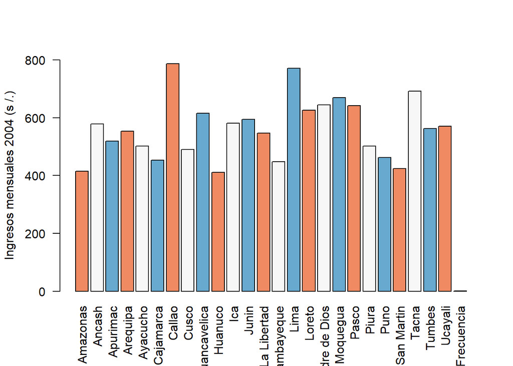

Data frame con ingresos promedio registrados por región para el año 2005:

```
##         Regiones Ingresos
## 1       Amazonas   346.30
## 2         Ancash   577.70
## 3       Apurimac   444.94
## 4       Arequipa   557.93
## 5       Ayacucho   515.31
## 6      Cajamarca   500.16
## 7         Callao   714.15
## 8          Cusco   484.26
## 9   Huancavelica   566.26
## 10       Huanuco   422.26
## 11           Ica   597.62
## 12         Junin   641.73
## 13   La Libertad   594.53
## 14    Lambayeque   499.28
## 15          Lima   787.83
## 16        Loreto   612.99
## 17 Madre de Dios   655.52
## 18      Moquegua   734.14
## 19         Pasco   636.24
## 20         Piura   459.43
## 21          Puno   469.91
## 22    San Martin   434.89
## 23         Tacna   693.19
## 24        Tumbes   596.60
## 25       Ucayali   564.57
## 26    Frecuencia     1.00
```

Gráfico a partir del año 2005:

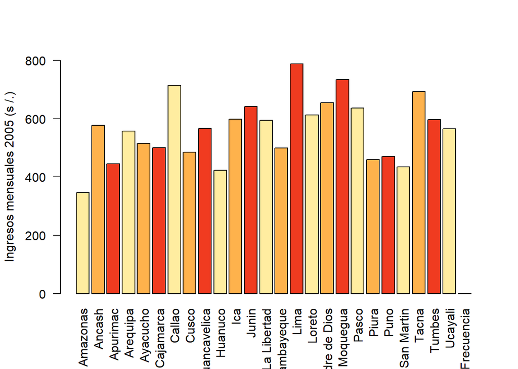

Data frame con ingresos promedio registrados por región para el año 2006:

```
##         Regiones Ingresos
## 1       Amazonas   407.18
## 2         Ancash   608.11
## 3       Apurimac   564.59
## 4       Arequipa   598.34
## 5       Ayacucho   524.35
## 6      Cajamarca   520.66
## 7         Callao   767.32
## 8          Cusco   545.90
## 9   Huancavelica   526.17
## 10       Huanuco   557.05
## 11           Ica   655.79
## 12         Junin   685.48
## 13   La Libertad   583.47
## 14    Lambayeque   504.90
## 15          Lima   862.06
## 16        Loreto   650.80
## 17 Madre de Dios   714.36
## 18      Moquegua   812.41
## 19         Pasco   593.76
## 20         Piura   517.22
## 21          Puno   546.29
## 22    San Martin   390.42
## 23         Tacna   743.48
## 24        Tumbes   654.20
## 25       Ucayali   536.66
## 26    Frecuencia     1.00
```

Gráfico a partir del año 2006:

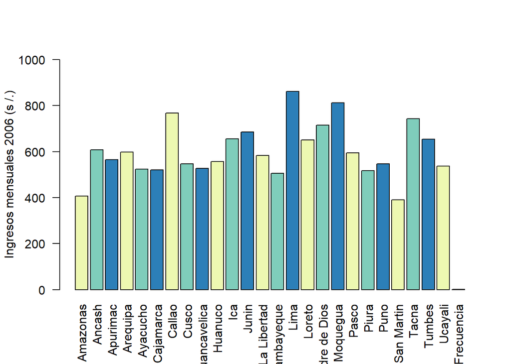

Data frame con ingresos promedio registrados por región para el año 2007:

```
##         Regiones Ingresos
## 1       Amazonas   486.14
## 2         Ancash   636.42
## 3       Apurimac   635.63
## 4       Arequipa   753.91
## 5       Ayacucho   557.52
## 6      Cajamarca   534.35
## 7         Callao   838.44
## 8          Cusco   666.23
## 9   Huancavelica   677.20
## 10       Huanuco   492.83
## 11           Ica   667.24
## 12         Junin   652.50
## 13   La Libertad   716.79
## 14    Lambayeque   589.54
## 15          Lima   931.42
## 16        Loreto   655.59
## 17 Madre de Dios   790.25
## 18      Moquegua  1077.38
## 19         Pasco   676.06
## 20         Piura   611.64
## 21          Puno   540.37
## 22    San Martin   596.24
## 23         Tacna   789.23
## 24        Tumbes   652.89
## 25       Ucayali   628.87
## 26    Frecuencia     1.00
```

Gráfico a partir del año 2007:

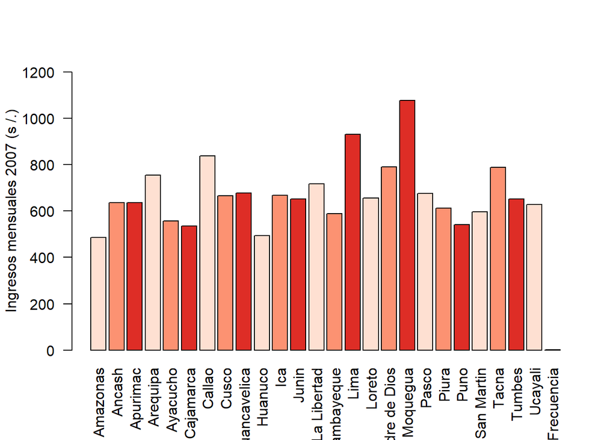

Data frame con ingresos promedio registrados por región para el año 2008:

```
##         Regiones Ingresos
## 1       Amazonas   544.82
## 2         Ancash   700.38
## 3       Apurimac   625.73
## 4       Arequipa   815.03
## 5       Ayacucho   572.95
## 6      Cajamarca   664.88
## 7         Callao   906.09
## 8          Cusco   691.16
## 9   Huancavelica   756.25
## 10       Huanuco   545.45
## 11           Ica   713.24
## 12         Junin   708.75
## 13   La Libertad   716.79
## 14    Lambayeque   630.83
## 15          Lima   962.36
## 16        Loreto   764.49
## 17 Madre de Dios   830.13
## 18      Moquegua  1216.08
## 19         Pasco   793.80
## 20         Piura   620.77
## 21          Puno   606.37
## 22    San Martin   688.92
## 23         Tacna   943.39
## 24        Tumbes   709.31
## 25       Ucayali   658.88
## 26    Frecuencia     1.00
```

Gráfico a partir del año 2008:

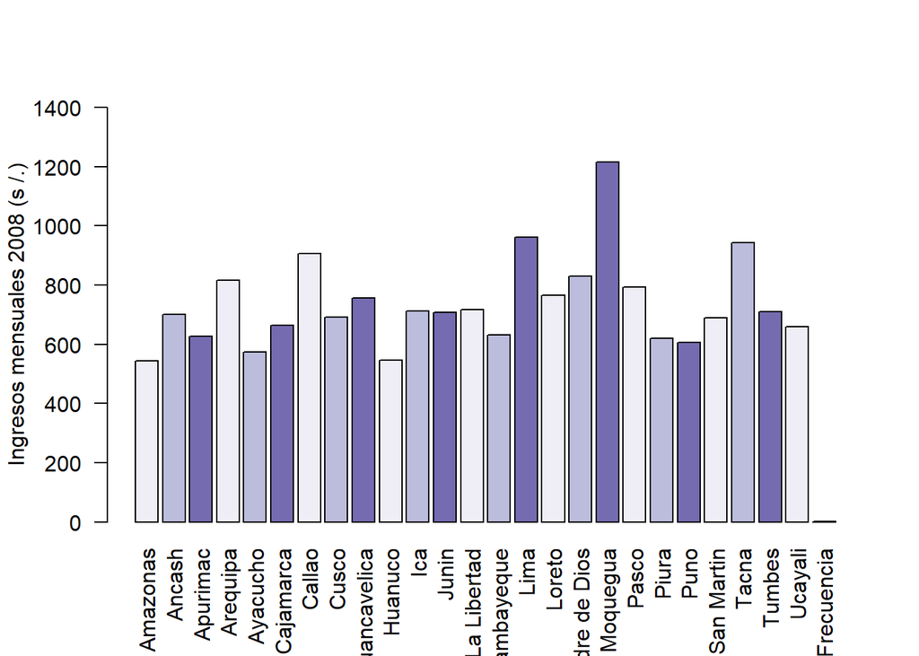

Data frame con ingresos promedio registrados por región para el año 2009:

```
##         Regiones Ingresos
## 1       Amazonas   582.81
## 2         Ancash   679.33
## 3       Apurimac   621.18
## 4       Arequipa   900.27
## 5       Ayacucho   641.65
## 6      Cajamarca   658.70
## 7         Callao  1019.98
## 8          Cusco   791.30
## 9   Huancavelica   811.65
## 10       Huanuco   594.10
## 11           Ica   823.63
## 12         Junin   716.58
## 13   La Libertad   803.01
## 14    Lambayeque   668.99
## 15          Lima  1066.03
## 16        Loreto   772.63
## 17 Madre de Dios   943.73
## 18      Moquegua  1306.02
## 19         Pasco   875.54
## 20         Piura   725.00
## 21          Puno   696.26
## 22    San Martin   718.43
## 23         Tacna  1021.54
## 24        Tumbes   758.42
## 25       Ucayali   753.44
## 26    Frecuencia     1.00
```

Gráfico a partir del año 2009:

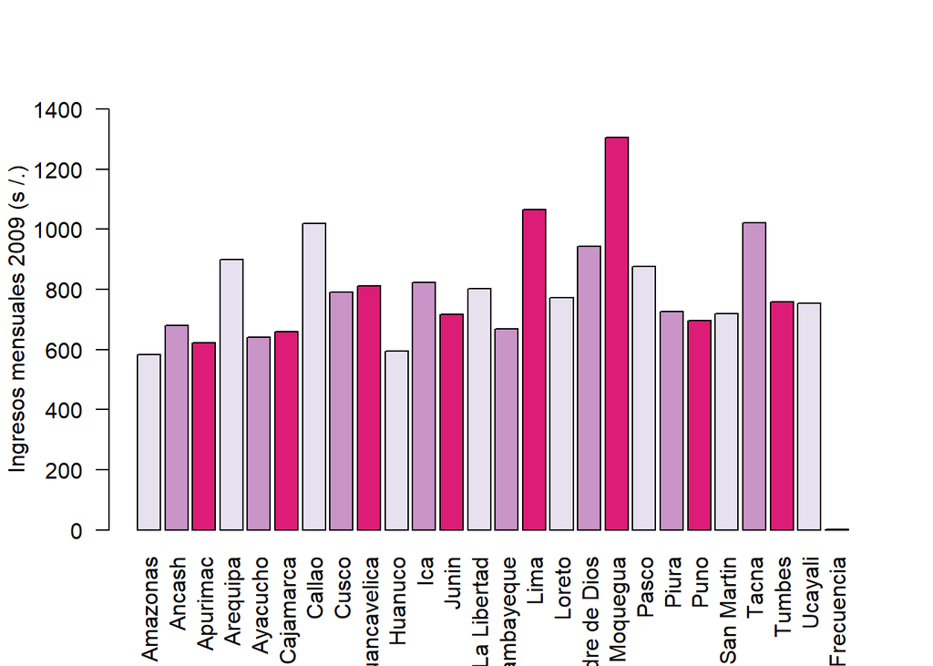

Data frame con ingresos promedio registrados por región para el año 2010:

```
##         Regiones Ingresos
## 1       Amazonas   584.00
## 2         Ancash   679.53
## 3       Apurimac   599.84
## 4       Arequipa   841.72
## 5       Ayacucho   672.82
## 6      Cajamarca   728.29
## 7         Callao  1002.91
## 8          Cusco   772.85
## 9   Huancavelica   813.20
## 10       Huanuco   621.31
## 11           Ica   836.08
## 12         Junin   746.69
## 13   La Libertad   797.33
## 14    Lambayeque   710.74
## 15          Lima  1097.66
## 16        Loreto   782.47
## 17 Madre de Dios   944.16
## 18      Moquegua  1351.90
## 19         Pasco   889.59
## 20         Piura   753.41
## 21          Puno   668.61
## 22    San Martin   817.12
## 23         Tacna  1025.41
## 24        Tumbes   769.46
## 25       Ucayali   780.56
## 26    Frecuencia     1.00
```

Gráfico a partir del año 2010:

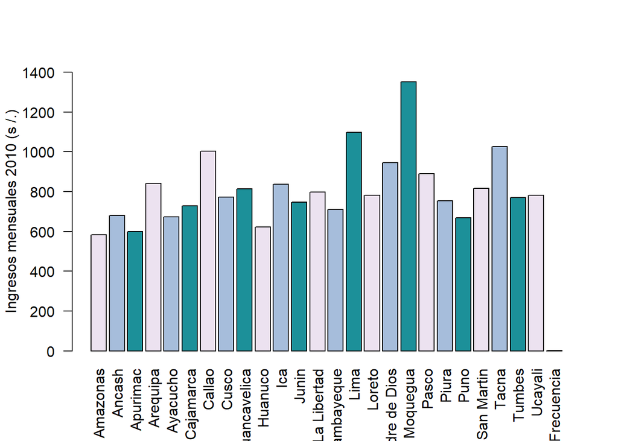

Data frame con ingresos promedio registrados por región para el año 2011:

```
##         Regiones Ingresos
## 1       Amazonas   647.80
## 2         Ancash   807.58
## 3       Apurimac   540.63
## 4       Arequipa   973.67
## 5       Ayacucho   740.17
## 6      Cajamarca   796.18
## 7         Callao   995.39
## 8          Cusco   864.18
## 9   Huancavelica   943.93
## 10       Huanuco   708.56
## 11           Ica   891.55
## 12         Junin   842.10
## 13   La Libertad   859.34
## 14    Lambayeque   758.65
## 15          Lima  1152.34
## 16        Loreto   907.13
## 17 Madre de Dios  1057.02
## 18      Moquegua  1394.82
## 19         Pasco   902.04
## 20         Piura   798.98
## 21          Puno   706.22
## 22    San Martin   752.89
## 23         Tacna  1103.71
## 24        Tumbes   871.07
## 25       Ucayali   851.95
## 26    Frecuencia     1.00
```

Gráfico a partir del año 2011:

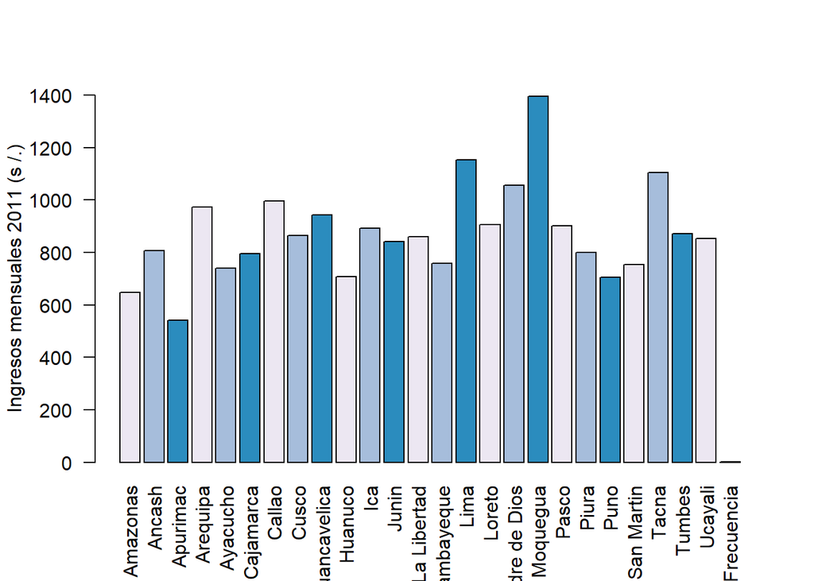

Data frame con ingresos promedio registrados por región para el año 2012:

```
##         Regiones Ingresos
## 1       Amazonas   751.10
## 2         Ancash   855.12
## 3       Apurimac   696.13
## 4       Arequipa  1055.12
## 5       Ayacucho   824.73
## 6      Cajamarca   890.99
## 7         Callao  1163.19
## 8          Cusco   920.30
## 9   Huancavelica   880.71
## 10       Huanuco   840.47
## 11           Ica   929.31
## 12         Junin   899.65
## 13   La Libertad   896.12
## 14    Lambayeque   841.95
## 15          Lima  1235.59
## 16        Loreto   967.48
## 17 Madre de Dios  1152.26
## 18      Moquegua  1481.24
## 19         Pasco   929.58
## 20         Piura   864.13
## 21          Puno   758.15
## 22    San Martin   860.39
## 23         Tacna  1174.79
## 24        Tumbes   991.39
## 25       Ucayali   906.75
## 26    Frecuencia     1.00
```

Gráfico a partir del año 2012:

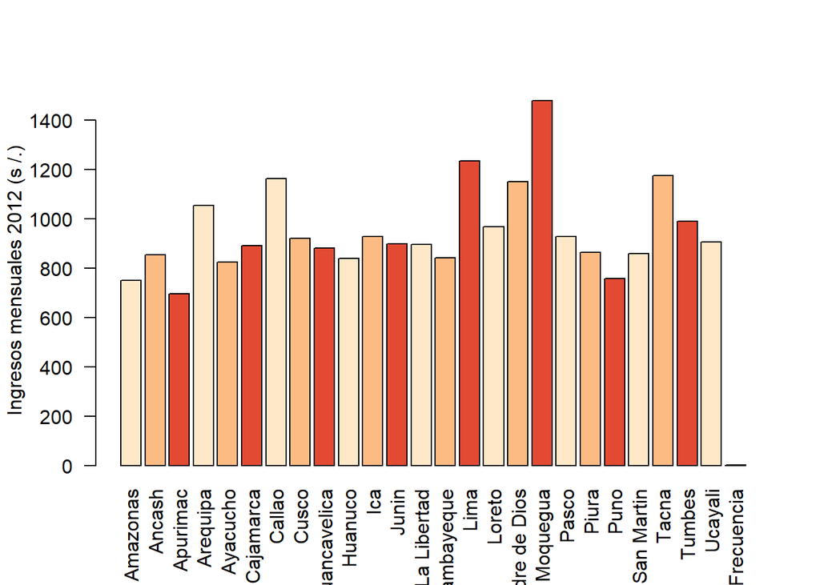

Data frame con ingresos promedio registrados por región para el año 2013:

```
##         Regiones Ingresos
## 1       Amazonas   777.79
## 2         Ancash   956.63
## 3       Apurimac   720.13
## 4       Arequipa  1156.73
## 5       Ayacucho   935.94
## 6      Cajamarca  1002.43
## 7         Callao  1228.40
## 8          Cusco  1017.30
## 9   Huancavelica   911.90
## 10       Huanuco   900.73
## 11           Ica  1021.63
## 12         Junin   965.14
## 13   La Libertad   957.70
## 14    Lambayeque   905.71
## 15          Lima  1385.20
## 16        Loreto  1015.52
## 17 Madre de Dios  1201.81
## 18      Moquegua  1630.16
## 19         Pasco   977.80
## 20         Piura   951.91
## 21          Puno   856.48
## 22    San Martin  1003.00
## 23         Tacna  1269.49
## 24        Tumbes  1066.91
## 25       Ucayali   932.78
## 26    Frecuencia     1.00
```

Gráfico a partir del año 2013:

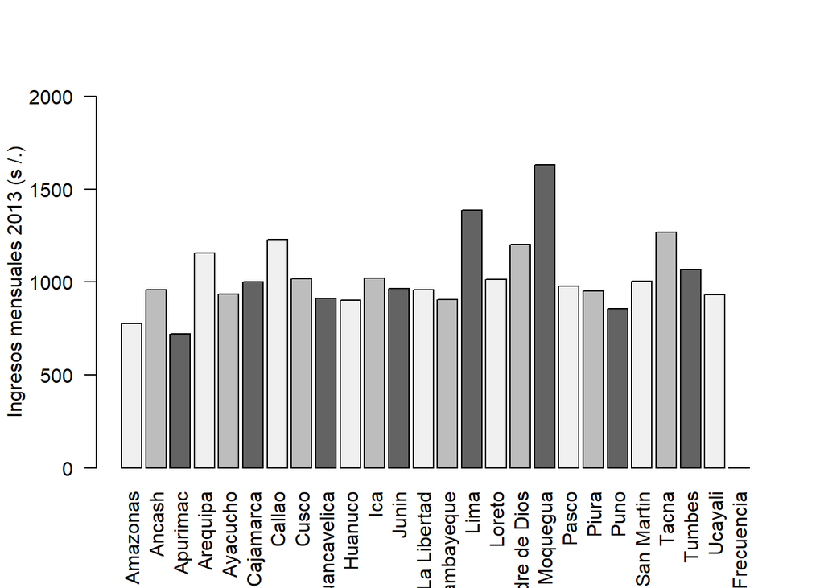

Data frame con ingresos promedio registrados por región para el año 2014:

```
##         Regiones Ingresos
## 1       Amazonas   813.93
## 2         Ancash  1040.14
## 3       Apurimac   863.23
## 4       Arequipa  1324.36
## 5       Ayacucho   930.88
## 6      Cajamarca   948.04
## 7         Callao  1384.78
## 8          Cusco  1143.06
## 9   Huancavelica   854.31
## 10       Huanuco   920.92
## 11           Ica  1140.94
## 12         Junin  1058.21
## 13   La Libertad   980.75
## 14    Lambayeque   973.95
## 15          Lima  1492.38
## 16        Loreto  1144.07
## 17 Madre de Dios  1275.31
## 18      Moquegua  1887.69
## 19         Pasco   977.81
## 20         Piura   991.92
## 21          Puno   944.61
## 22    San Martin   951.96
## 23         Tacna  1322.29
## 24        Tumbes  1121.37
## 25       Ucayali   924.04
## 26    Frecuencia     1.00
```

Gráfico a partir del año 2014:

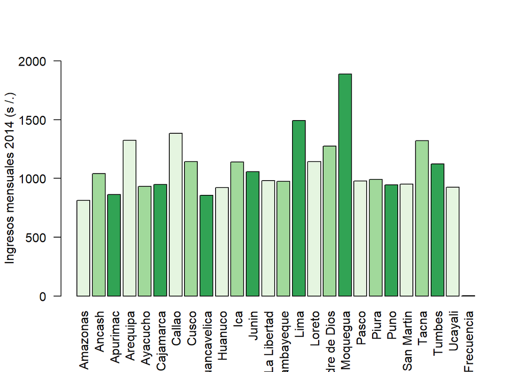

Data frame con ingresos promedio registrados por región para el año 2015:

```
##         Regiones Ingresos
## 1       Amazonas   940.35
## 2         Ancash  1018.55
## 3       Apurimac   869.84
## 4       Arequipa  1349.05
## 5       Ayacucho   878.84
## 6      Cajamarca  1052.14
## 7         Callao  1426.15
## 8          Cusco  1129.76
## 9   Huancavelica   981.58
## 10       Huanuco   954.68
## 11           Ica  1168.30
## 12         Junin  1101.08
## 13   La Libertad   996.17
## 14    Lambayeque  1003.32
## 15          Lima  1571.76
## 16        Loreto  1185.30
## 17 Madre de Dios  1270.93
## 18      Moquegua  1793.87
## 19         Pasco   999.35
## 20         Piura  1014.43
## 21          Puno  1025.38
## 22    San Martin  1008.13
## 23         Tacna  1412.86
## 24        Tumbes  1244.26
## 25       Ucayali  1138.66
## 26    Frecuencia     1.00
```

Gráfico a partir del año 2015:

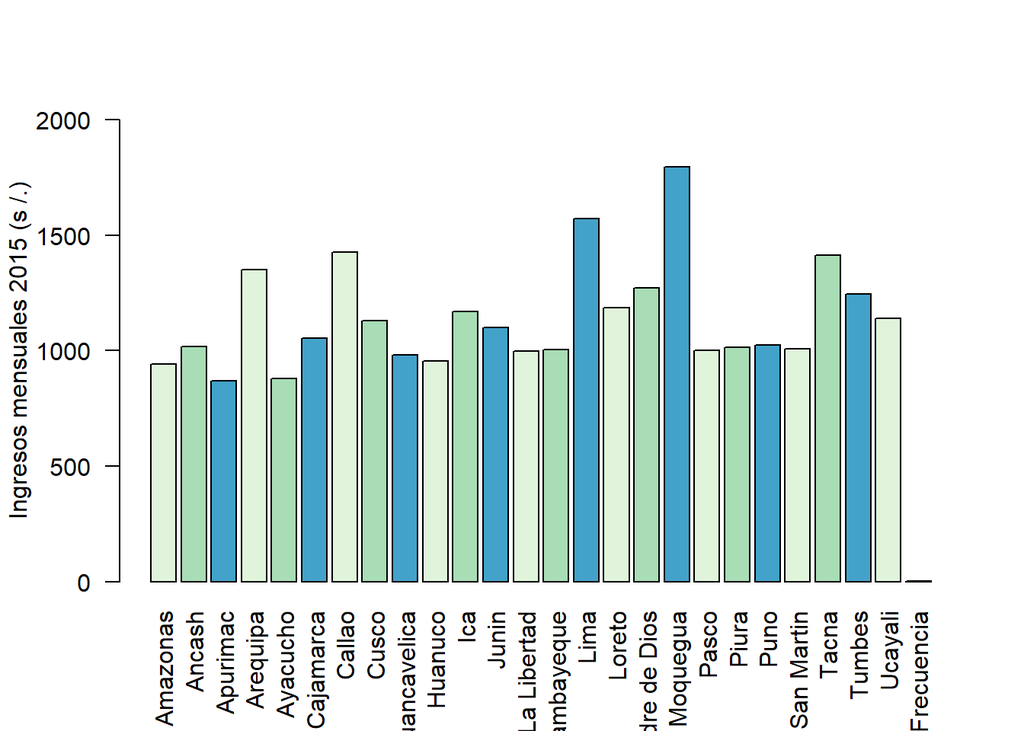

Data frame con ingresos promedio registrados por región para el año 2016:

```
##         Regiones Ingresos
## 1       Amazonas   987.80
## 2         Ancash  1125.08
## 3       Apurimac   911.75
## 4       Arequipa  1346.46
## 5       Ayacucho   986.11
## 6      Cajamarca  1106.90
## 7         Callao  1434.69
## 8          Cusco  1254.69
## 9   Huancavelica   973.81
## 10       Huanuco  1070.96
## 11           Ica  1247.88
## 12         Junin  1182.44
## 13   La Libertad  1121.59
## 14    Lambayeque  1160.68
## 15          Lima  1726.86
## 16        Loreto  1282.97
## 17 Madre de Dios  1411.22
## 18      Moquegua  1748.74
## 19         Pasco  1136.77
## 20         Piura  1054.06
## 21          Puno  1060.60
## 22    San Martin  1094.18
## 23         Tacna  1338.41
## 24        Tumbes  1309.28
## 25       Ucayali  1131.40
## 26    Frecuencia     1.00
```

Gráfico a partir del año 2016:

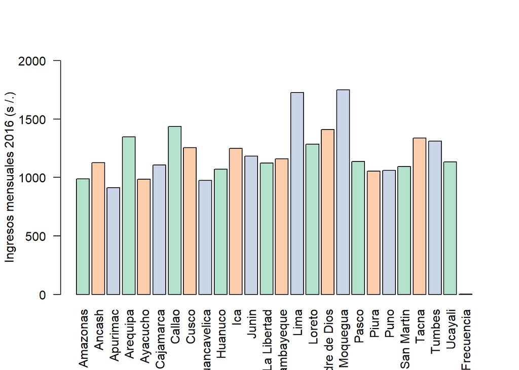

Data frame con ingresos promedio registrados por región para el año 2017:

```
##         Regiones Ingresos
## 1       Amazonas  1009.66
## 2         Ancash  1131.39
## 3       Apurimac   936.69
## 4       Arequipa  1416.87
## 5       Ayacucho  1125.01
## 6      Cajamarca  1089.26
## 7         Callao  1483.62
## 8          Cusco  1237.42
## 9   Huancavelica   938.54
## 10       Huanuco  1099.73
## 11           Ica  1304.47
## 12         Junin  1166.92
## 13   La Libertad  1175.97
## 14    Lambayeque  1141.84
## 15          Lima  1673.98
## 16        Loreto  1409.53
## 17 Madre de Dios  1380.22
## 18      Moquegua  1921.26
## 19         Pasco  1211.35
## 20         Piura  1222.04
## 21          Puno   956.42
## 22    San Martin  1166.06
## 23         Tacna  1529.15
## 24        Tumbes  1356.26
## 25       Ucayali  1110.17
## 26    Frecuencia     1.00
```

Gráfico a partir del año 2017:

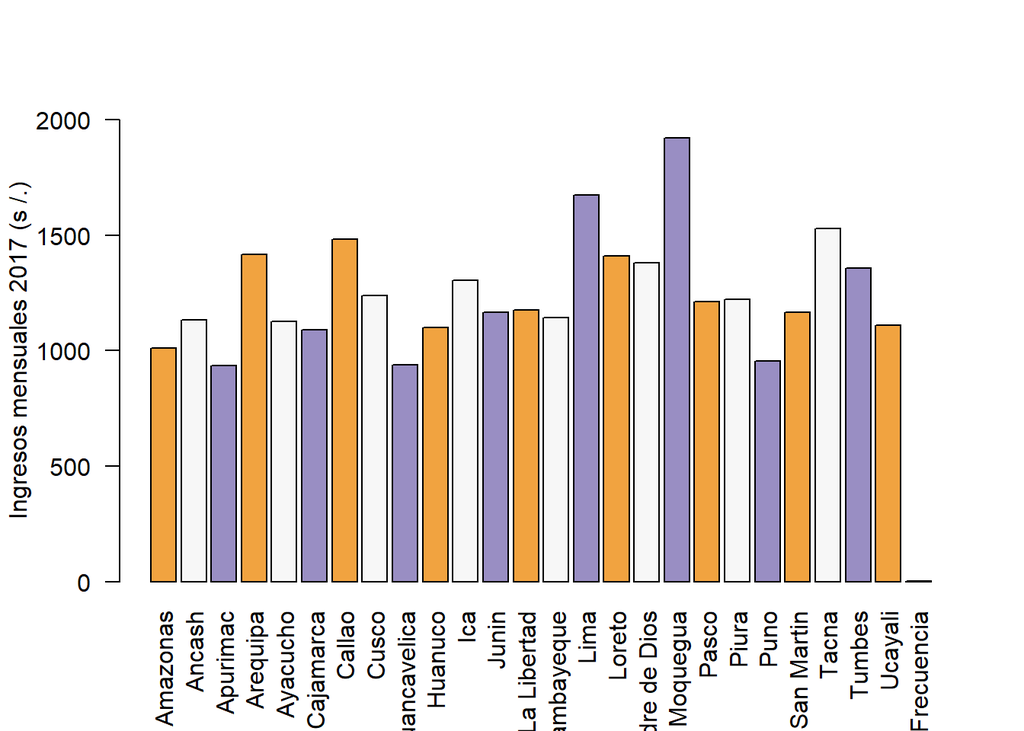

Data frame con ingresos promedio registrados por región para el año 2018:

```
##         Regiones Ingresos
## 1       Amazonas  1036.30
## 2         Ancash  1175.02
## 3       Apurimac   974.76
## 4       Arequipa  1462.43
## 5       Ayacucho  1100.44
## 6      Cajamarca  1099.28
## 7         Callao  1515.18
## 8          Cusco  1393.36
## 9   Huancavelica   970.49
## 10       Huanuco  1117.64
## 11           Ica  1390.34
## 12         Junin  1243.28
## 13   La Libertad  1232.42
## 14    Lambayeque  1226.02
## 15          Lima  1714.58
## 16        Loreto  1477.08
## 17 Madre de Dios  1412.69
## 18      Moquegua  1867.90
## 19         Pasco  1174.31
## 20         Piura  1243.60
## 21          Puno  1062.11
## 22    San Martin  1249.34
## 23         Tacna  1577.79
## 24        Tumbes  1309.28
## 25       Ucayali  1219.34
## 26    Frecuencia     1.00
```

Gráfico a partir del año 2018:

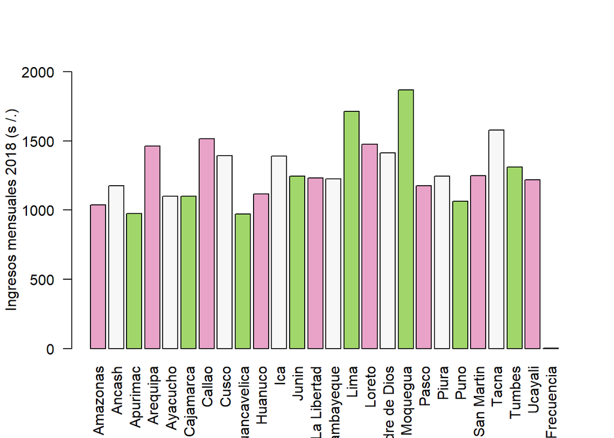

Data frame con ingresos promedio registrados por región para el año 2019:

```
##         Regiones Ingresos
## 1       Amazonas  1043.77
## 2         Ancash  1261.87
## 3       Apurimac  1161.77
## 4       Arequipa  1556.03
## 5       Ayacucho  1078.45
## 6      Cajamarca  1267.12
## 7         Callao  1509.57
## 8          Cusco  1474.28
## 9   Huancavelica  1016.68
## 10       Huanuco  1049.03
## 11           Ica  1444.03
## 12         Junin  1190.07
## 13   La Libertad  1289.29
## 14    Lambayeque  1165.73
## 15          Lima  1764.62
## 16        Loreto  1561.21
## 17 Madre de Dios  1460.82
## 18      Moquegua  1923.77
## 19         Pasco  1280.12
## 20         Piura  1232.31
## 21          Puno  1021.38
## 22    San Martin  1170.59
## 23         Tacna  1579.42
## 24        Tumbes  1389.57
## 25       Ucayali  1191.49
## 26    Frecuencia     1.00
```

Gráfico a partir del año 2019:

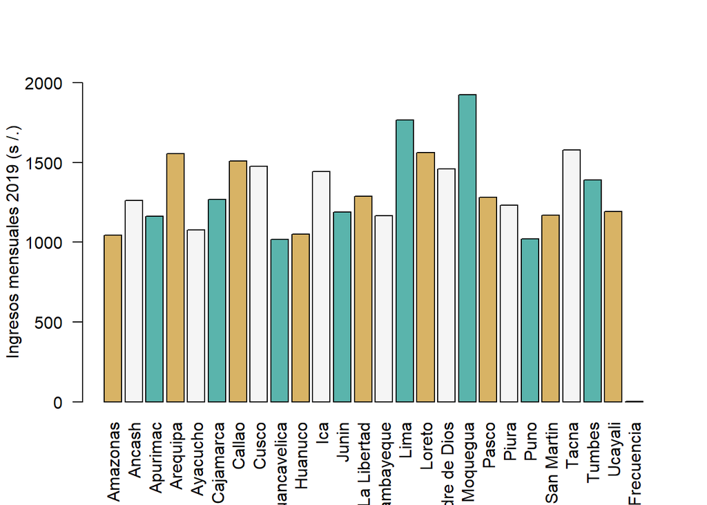

Data frame con ingresos promedio registrados por región para el año 2020:

```
##         Regiones Ingresos
## 1       Amazonas  1099.63
## 2         Ancash  1293.46
## 3       Apurimac  1308.11
## 4       Arequipa  1502.44
## 5       Ayacucho  1138.54
## 6      Cajamarca  1240.53
## 7         Callao  1526.48
## 8          Cusco  1411.43
## 9   Huancavelica  1045.92
## 10       Huanuco  1135.04
## 11           Ica  1498.63
## 12         Junin  1261.92
## 13   La Libertad  1332.81
## 14    Lambayeque  1282.89
## 15          Lima  1702.37
## 16        Loreto  1563.73
## 17 Madre de Dios  1462.81
## 18      Moquegua  1950.97
## 19         Pasco  1240.12
## 20         Piura  1213.25
## 21          Puno  1053.56
## 22    San Martin  1231.64
## 23         Tacna  1514.67
## 24        Tumbes  1414.99
## 25       Ucayali  1315.04
## 26    Frecuencia     1.00
```

Gráfico a partir del año 2020:

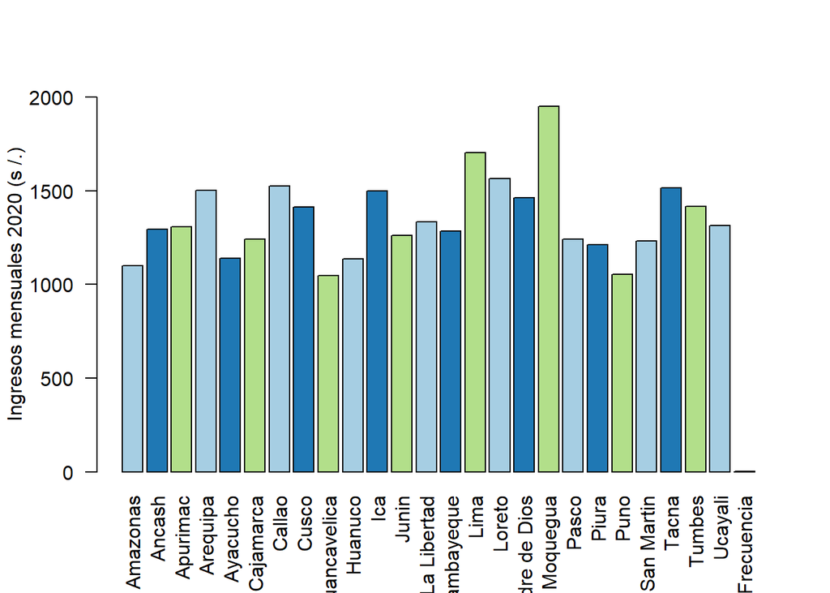

*PATRONES*

*1er patrón encontrado*

En la serie de patrones encontrados tras el análisis de la data obtenida podemos observar los siguientes: La región o departamento con Mayor ingreso promedio en soles es Moquegua, que tiene este puesto desde el año 2007 hasta el 2020, que es el último año con data registrada para este proyecto. Esto ocurre ya que de la población encuestada(personas de 14 años a más) el 75% aproximadamente constituye la población económicamente activa, donde el 72% son personas con alguna ocupación mientras que el 3% es desocupada. La reducción de la pobreza y el aumento de ingresos se da porque se presentan mayores oportunidades de empleo y acceso de mercado que genera un crecimiento económico sostenido.

Data frame de región con mayor ingreso por año

```
##     Año   Región Ingreso
## 1  2004   Callao  787.24
## 2  2005     Lima  787.83
## 3  2006     Lima  862.06
## 4  2007 Moquegua 1077.38
## 5  2008 Moquegua 1216.08
## 6  2009 Moquegua 1306.02
## 7  2010 Moquegua 1351.90
## 8  2011 Moquegua 1394.82
## 9  2012 Moquegua 1481.24
## 10 2013 Moquegua 1630.16
## 11 2014 Moquegua 1887.69
## 12 2015 Moquegua 1793.87
## 13 2016 Moquegua 1748.74
## 14 2017 Moquegua 1921.26
## 15 2018 Moquegua 1867.90
## 16 2019 Moquegua 1923.77
## 17 2020 Moquegua 1950.97
```

*2do patron encontrado*

Justificaciones para Huánuco y Apurímac regiones con mayor presencía a lo largo de los años como regiones con menor ingreso promedio:

- Solo dos provincias de la región de Huánuco, como son Leoncio Prado y Huánuco generan mayor economía para el departamento.
- Nivel de informalidad de Apurímac (88%) sobre el promedio nacional (72%).

Data frame de región con menor ingreso por año

```
##     Año       Región Ingreso
## 1  2004      Huánuco  410.62
## 2  2005     Amazonas  346.30
## 3  2006   San Martin  390.42
## 4  2007      Huánuco  492.83
## 5  2008      Huánuco  545.45
## 6  2009      Huánuco  594.10
## 7  2010      Huánuco  621.31
## 8  2011      Huánuco  708.56
## 9  2012     Apurímac  696.13
## 10 2013     Apurímac  720.13
## 11 2014 Huancavelica  854.31
## 12 2015     Apurímac  869.84
## 13 2016     Apurímac  911.75
## 14 2017     Apurímac  936.69
## 15 2018 Huancavelica  970.49
## 16 2019         Puno 1021.38
## 17 2020 Huancavelica 1045.92
```

*3er patron encontrado*

Los ingresos promedio de cada región son variables, ya que pueden aumentar o disminuir en un rango de 200 por año. Aunque si comparamos los ingresos del primer y último año, se ve un aumento robusto en todas la regiones.

*4to patron encontrado*

Data frame y gráfica que refleja la diferencia entre la región con mayor y menor ingreso para cada año

[output not shown]

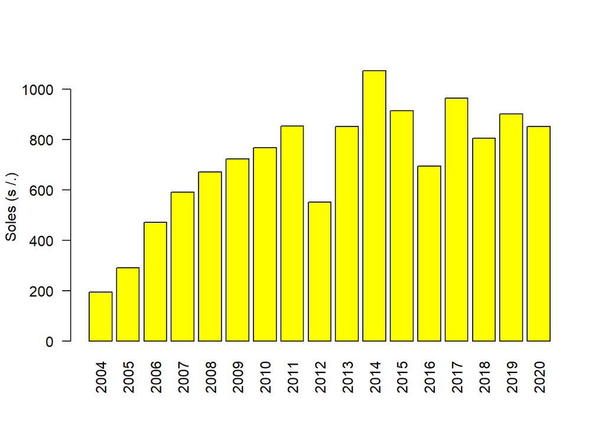

*VARIABLES ALEATORIAS*

Tabla de probabilidad de variable aleatoria: 2 variable aleatorias. Una es escoger a una persona de una region, la segunda es si esta persona gana mas que el sueldo mínimo o no.

*Variables Aleatorias 2004*

En la siguiente tabla, se muestra tres probabilidades distintas por region expresadas en las filas. La primera fila llamada “escoger region” muestra la probabilidad de que al escoger una persona entrevistada , que esta se encuentre en una región específica. Ya que en ciertas regiones se ha entrevistado a mas gente, entonces la probabilidad varía segun la región. Su probabilidad se calcula dividiendo la cantidad de gente entrevistada en la región dividida entre la cantidad de entrevistados totales.

La segunda fila llamada “Mayor a sueldo mínimo” representa la probabilidad de que, teniendo como universo a la población entrevistada en una región específica, se escoga una persona que gane mas que el sueldo mínimo de 930 soles. Esta se calcula dividiendo la cantidad de gente dentro de una región que gana más de 930 soles entre la cantidad de gente que se encuentra en esta región. La última fila representa la probabilidad compuesta de haber escogido una región específica, y que luego esta persona gane más que el sueldo mínimo. Su cálculo es el producto de las dos filas anteriores.

|  | Amazonas | Ancash | Apurimac | Arequipa | Ayacucho | Cajamarca | Callao | Cusco | Huancavelica | Huanuco | Ica | Junin | La Libertad | Lambayeque | Lima | Loreto | Madre de Dios | Moquegua | Pasco | Piura | Puno | San Martin | Tacna | Tumbes | Ucayali |
| --- | --- | --- | --- | --- | --- | --- | --- | --- | --- | --- | --- | --- | --- | --- | --- | --- | --- | --- | --- | --- | --- | --- | --- | --- | --- |
| Escoger Region | 0.027 | 0.041 | 0.015 | 0.045 | 0.033 | 0.032 | 0.022 | 0.027 | 0.018 | 0.026 | 0.059 | 0.041 | 0.044 | 0.056 | 0.167 | 0.034 | 0.027 | 0.032 | 0.028 | 0.046 | 0.027 | 0.040 | 0.044 | 0.039 | 0.029 |
| Mayor a Sueldo Mínimo | 0.145 | 0.183 | 0.188 | 0.165 | 0.183 | 0.115 | 0.259 | 0.139 | 0.272 | 0.183 | 0.143 | 0.171 | 0.179 | 0.142 | 0.200 | 0.233 | 0.213 | 0.230 | 0.234 | 0.139 | 0.185 | 0.118 | 0.206 | 0.178 | 0.175 |
| Mayor a sueldo Mínimo * Escoger Región | 0.004 | 0.008 | 0.003 | 0.007 | 0.006 | 0.004 | 0.006 | 0.004 | 0.005 | 0.005 | 0.008 | 0.007 | 0.008 | 0.008 | 0.033 | 0.008 | 0.006 | 0.007 | 0.007 | 0.006 | 0.005 | 0.005 | 0.009 | 0.007 | 0.005 |

*Variables Aleatorias 2020*

Podemos ver lo mismo para el 2020

|  | Amazonas | Ancash | Apurimac | Arequipa | Ayacucho | Cajamarca | Callao | Cusco | Huancavelica | Huanuco | Ica | Junin | La Libertad | Lambayeque | Lima | Loreto | Madre de Dios | Moquegua | Pasco | Piura | Puno | San Martin | Tacna | Tumbes | Ucayali |
| --- | --- | --- | --- | --- | --- | --- | --- | --- | --- | --- | --- | --- | --- | --- | --- | --- | --- | --- | --- | --- | --- | --- | --- | --- | --- |
| Escoger Region | 0.031 | 0.038 | 0.019 | 0.057 | 0.027 | 0.024 | 0.039 | 0.020 | 0.017 | 0.026 | 0.058 | 0.037 | 0.051 | 0.054 | 0.173 | 0.038 | 0.019 | 0.029 | 0.020 | 0.062 | 0.025 | 0.038 | 0.040 | 0.023 | 0.035 |
| Mayor a Sueldo Mínimo | 0.409 | 0.543 | 0.555 | 0.685 | 0.473 | 0.477 | 0.742 | 0.597 | 0.446 | 0.442 | 0.757 | 0.520 | 0.601 | 0.563 | 0.696 | 0.655 | 0.633 | 0.735 | 0.556 | 0.578 | 0.453 | 0.480 | 0.622 | 0.644 | 0.579 |
| Mayor a sueldo Mínimo * Escoger Región | 0.013 | 0.021 | 0.011 | 0.039 | 0.013 | 0.011 | 0.029 | 0.012 | 0.008 | 0.011 | 0.044 | 0.019 | 0.031 | 0.030 | 0.120 | 0.025 | 0.012 | 0.021 | 0.011 | 0.036 | 0.011 | 0.018 | 0.025 | 0.015 | 0.020 |

*Boxplots*

Asímismo dentro de los descriptores gráficos del informe incluímos boxplots que reflejen los valores atípicos en cada año en cuanto al promedio de ingresos mensuales por región.

```
##  [1] "415.15" "578.86" "518.94" "552.72" "501.77" "453.73" "787.24" "490.35"
##  [9] "615.42" "410.62" "580.97" "594.83" "546.57" "447.39" "771.24" "626.21"
## [17] "644.19" "669.53" "641.74" "501.41" "461.83" "423.74" "691.37" "562.35"
## [25] "569.99" "1"
```

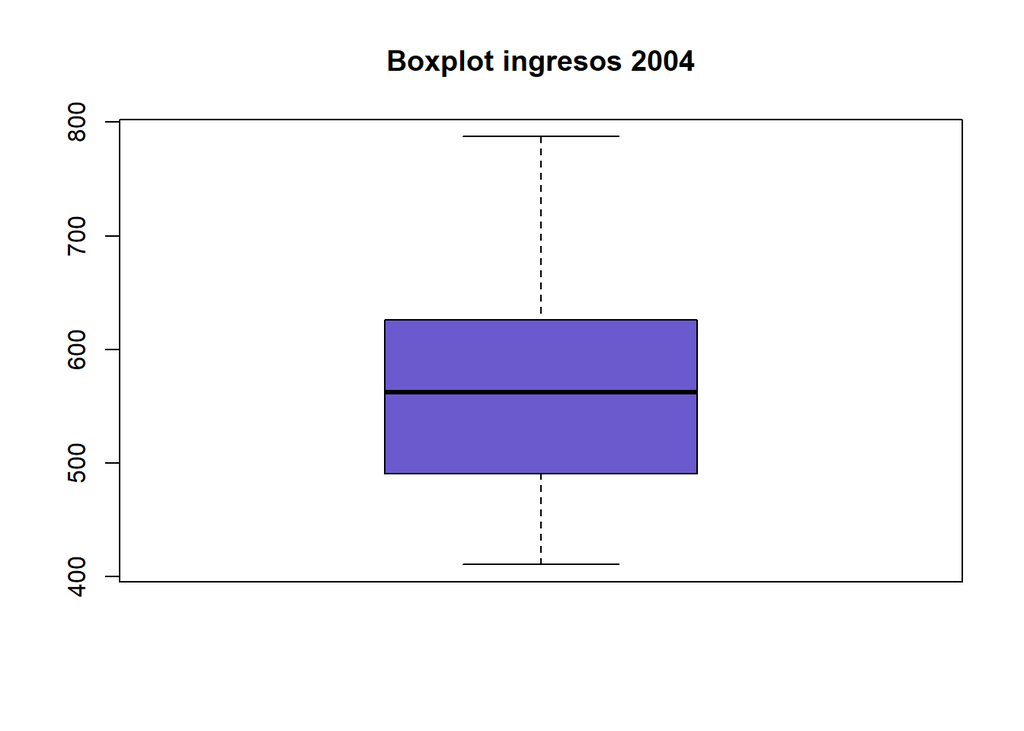

El boxplot del 2004 no presenta valores atípicos. Se puede concluir que se cuenta con valores no muy alejados de ingresos por región.

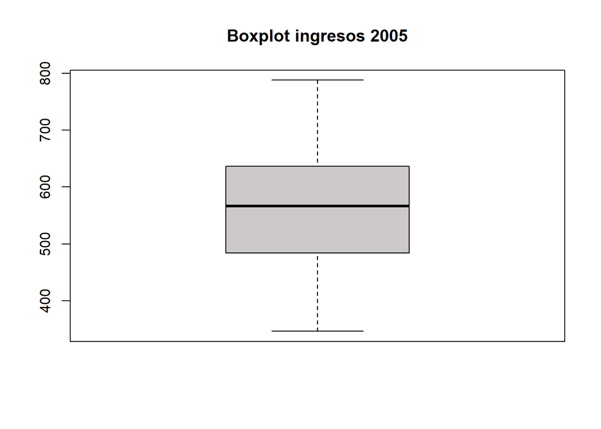

El boxplot del 2005 no presenta valores atípicos. Se puede concluir que se cuenta con valores no muy alejados de ingresos por región.

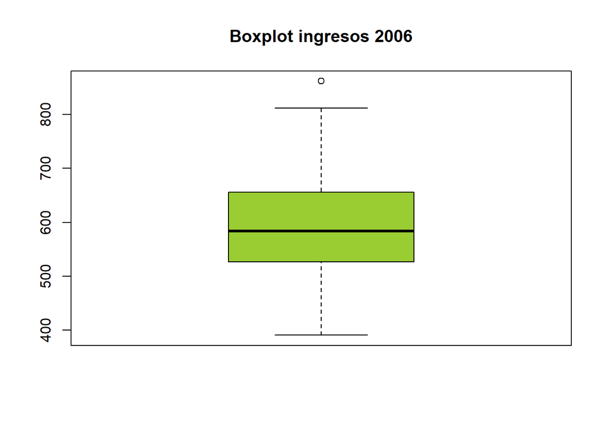

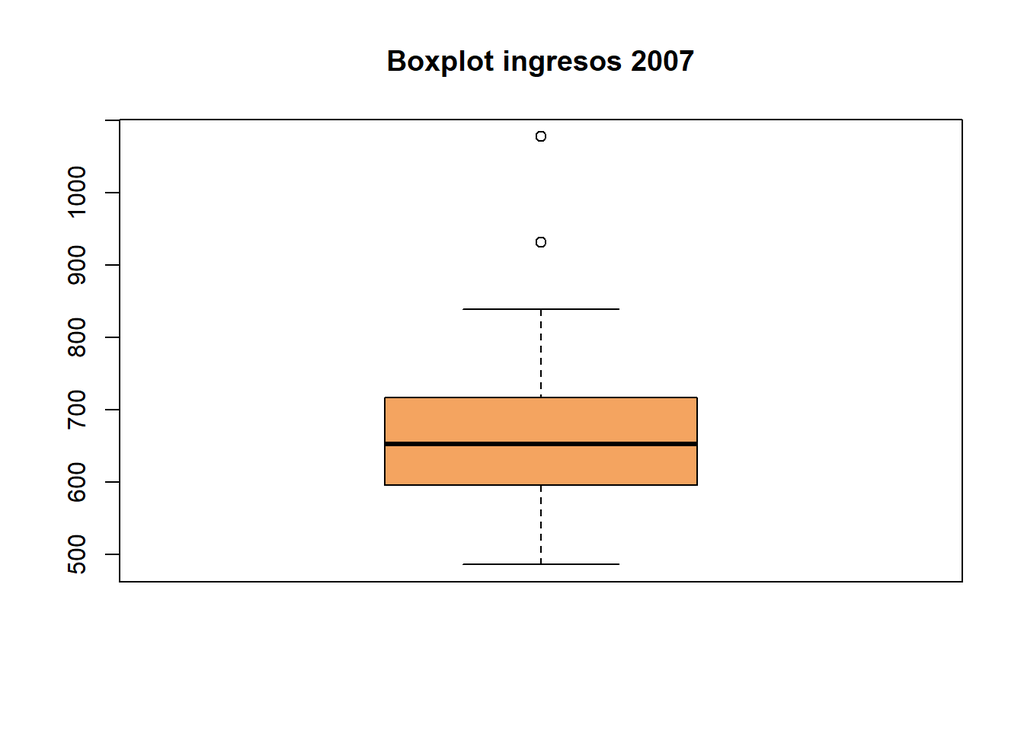

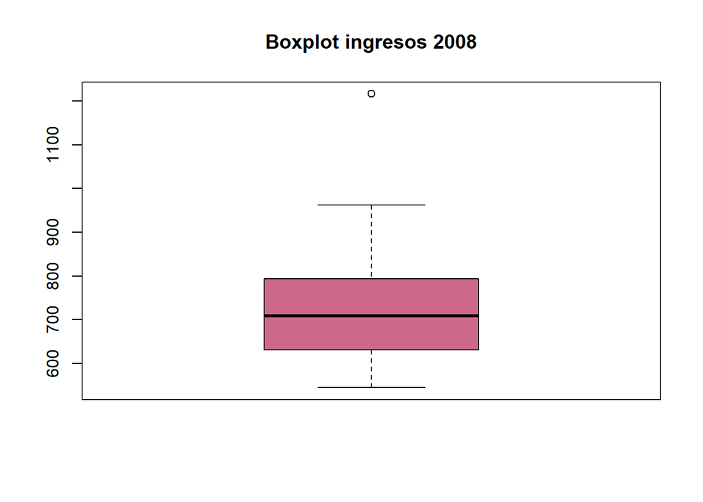

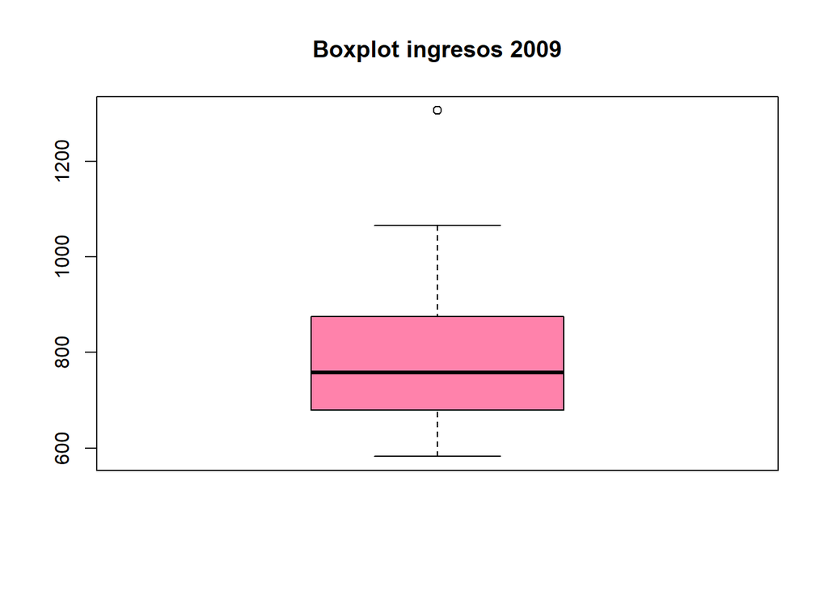

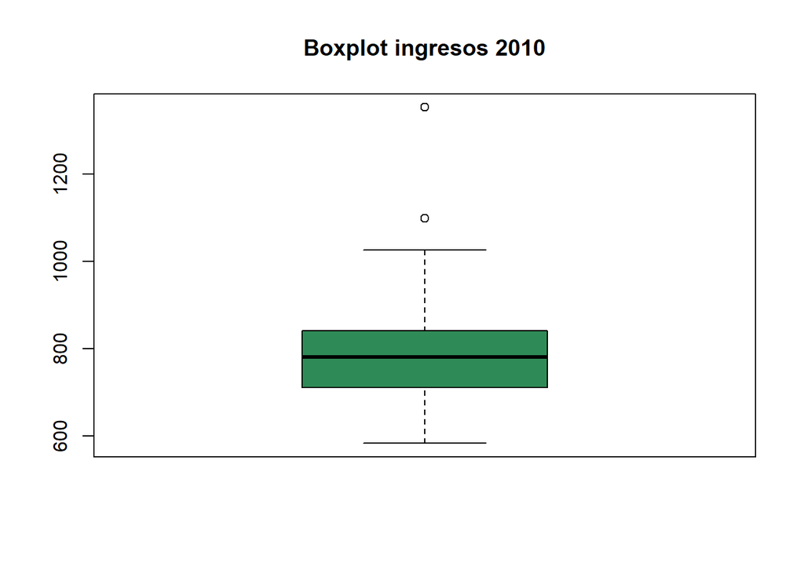

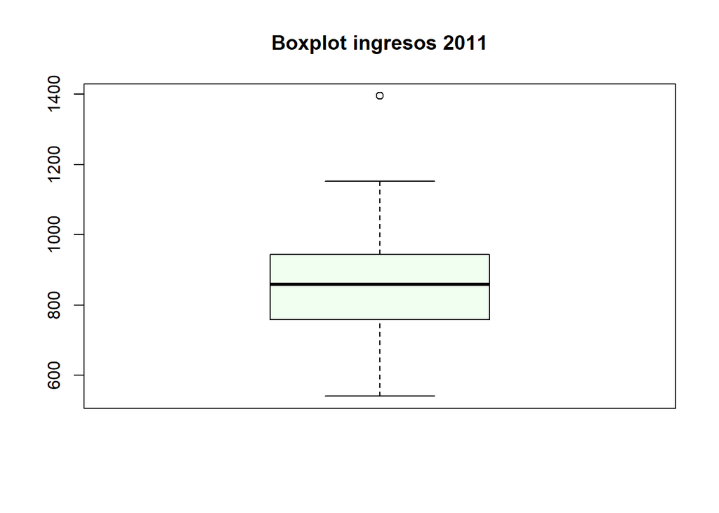

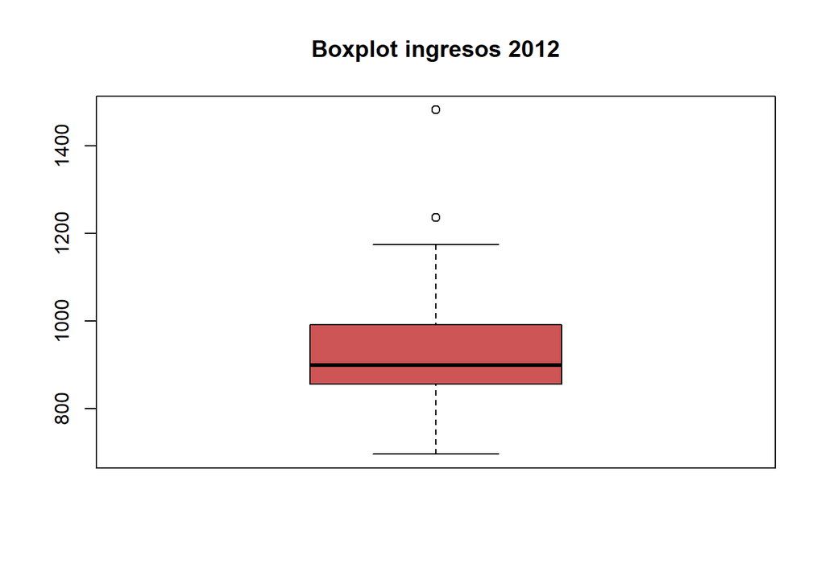

El boxplot del 2012 presenta 2 valores atípicos. Estos valores corresponden a las siguientes regiones y promedios de ingresos mensuales.

1481.24 –> Moquegua

1235.59 –> Lima

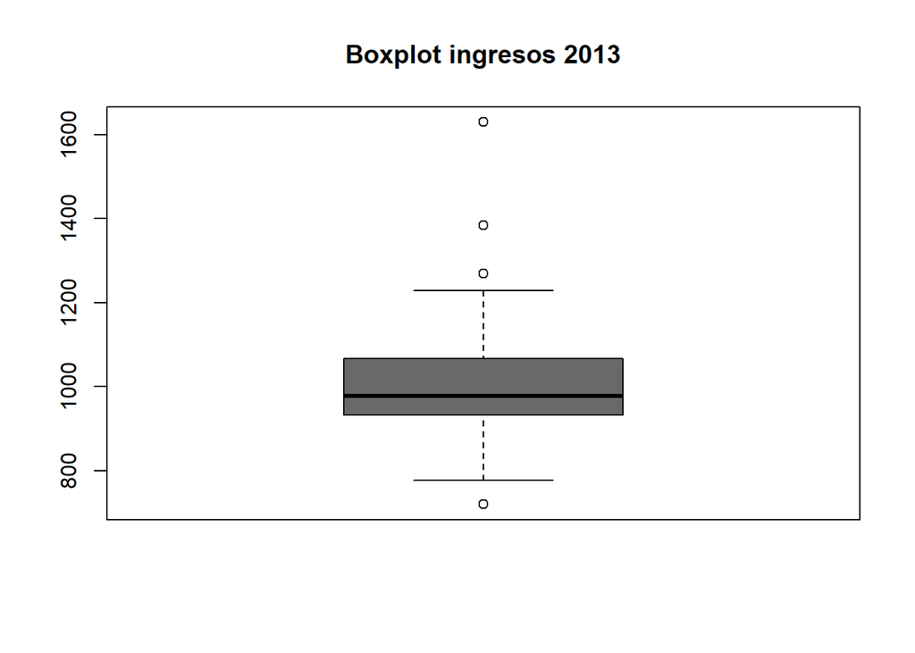

Valores atípicos mayores: 1630.16 –> Moquegua

1385.2 –> Lima

720.13 –> Apurímac

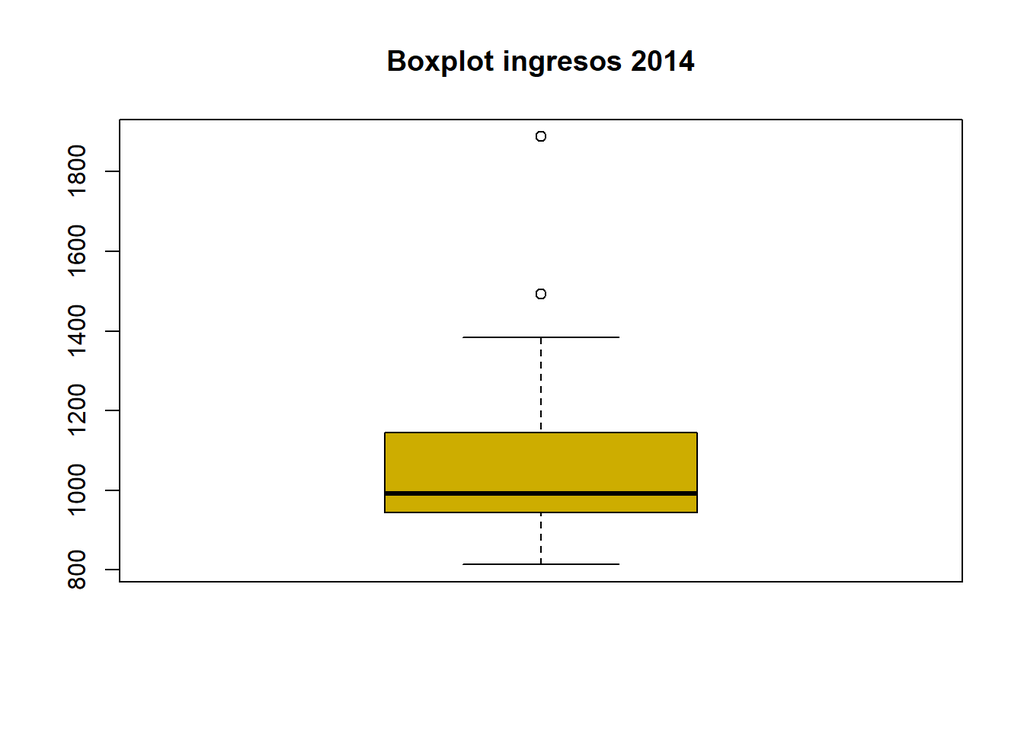

El boxplot del 2014 presenta 2 valores atípicos. Estos valores corresponden a las siguientes regiones y promedios de ingresos mensuales.

1887.69 –> Moquegua

1492.38 –> Lima

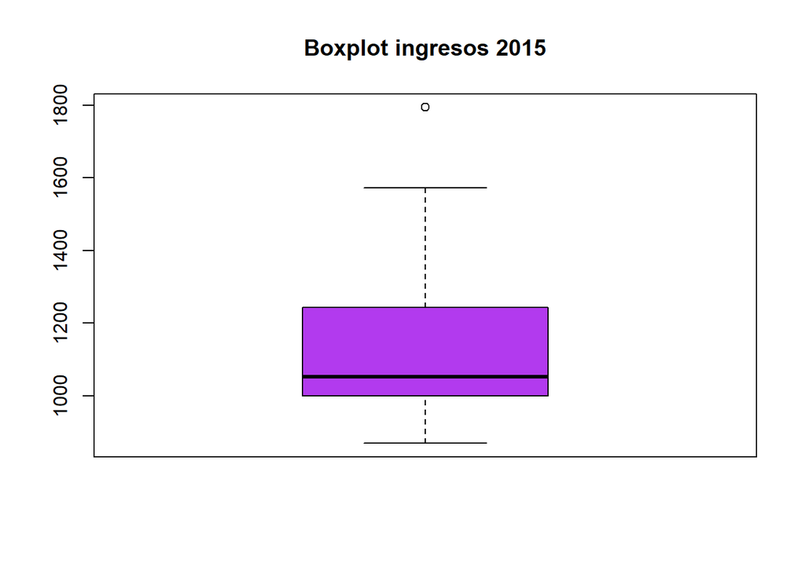

```
El boxplot del 2015 presenta 1 valor atípico. Este valor corresponde a la siguiente región y promedio de ingresos mensuales.

1793.87--> Moquegua
```

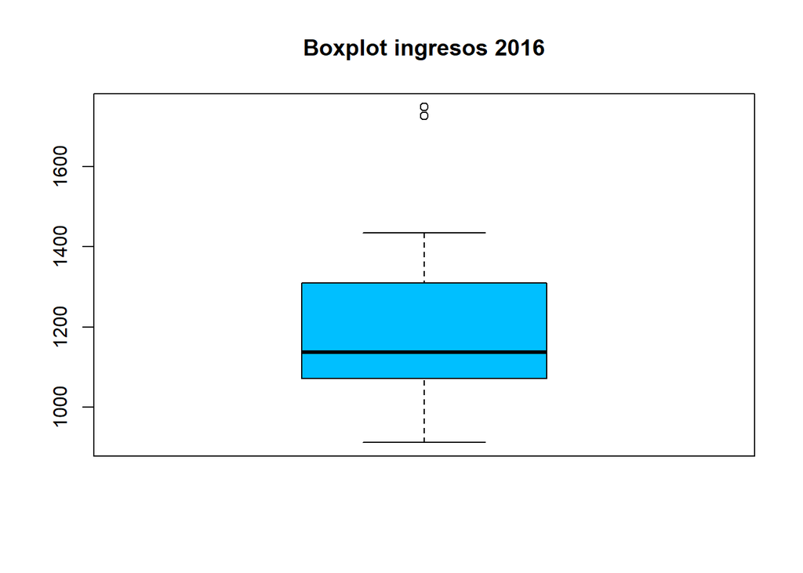

```
El boxplot del 2016 presenta 2 valores atípicos muy similares. Estos valores corresponden a las siguientes regiones y promedios de ingresos mensuales.
```

1748.74 –> Moquegua